# Time Series Forecasting - Practice Exercise - Week 3 - Solution

## AUTO REGRESSIVE Models

Auto-regressive (AR) and moving average (MA) models are popular models that are frequently used for forecasting.

AR and MA models are combined to create models such as auto-regressive moving average (ARMA) and auto-regressive integrated moving average (ARIMA) models.

The initial ARMA and ARIMA models were developed by Box and Jenkins in 1970.

ARMA models are basically regression models; auto-regression means regression of a variable on itself measured at different time periods.

The main assumption of AR model is that the time series data is stationary.

A stationary time series is one whose statistical properties such as mean, variance, autocorrelation, etc. are all constant over time.

http://people.duke.edu/~rnau/411diff.htm

When the time series data is not stationary, then we convert the non-stationary data before applying AR models.

### Lags

Taking the difference between consecutive observations is called a lag-1 difference.

For time series with a seasonal component, the lag may be expected to be the period (width) of the seasonality.

**White noise of the residuals:**

White noise is a process of residuals $\epsilon_t$ that are uncorrelated and follow normal distribution with mean 0 and constant standard deviation. In AR models, one of the main assumptions is the errors follow a white noise.

### Auto-Regressive (AR) Models

Auto-Regression is a regression of a variable on itself measured at different time points. Auto-Regressive model with lag 1, AR(1) is given by

- $Y_{t+1} = \beta Y_t + \epsilon_{t+1}$ and this same as
- $Y_{t+1} - \mu = \beta (Y_t - \mu) + \epsilon_{t+1}$ and this same as
- where $\epsilon_{t+1}$ is a sequence of uncorrelated residuals that follow normal distribution with zero mean and constant deviation.
  - $Y_{t+1} - \mu$ is interpreted as a deviation from mean value $mu$ and known as mean centered series.

The Augmented Dickey Fuller Test (ADF) is unit root test for stationarity. The null hypothesis is that time series is non-stationary. Alternative hypothesis is that time series is stationary.

### Auto-Correlation Function (ACF) or correlogram and Partial Auto-Correlation Function (PACF)

#### Autocorrelation Function (ACF)

**A plot of auto-correlation of different lags is called ACF.**

The plot summarizes the correlation of an observation with lag values. The x-axis shows the lag and the y-axis shows the correlation coeﬃcient between -1 and 1 for negative and positive correlation.

#### Partial Autocorrelation Function (PACF)

**A plot of partial auto-correlation for different values of lags is called PACF.**

The plot summarizes the correlations for an observation with lag values that is not accounted for by prior lagged observations.

Both plots are drawn as bar charts showing the 95% and 99% conﬁdence intervals as horizontal lines. Bars that cross these conﬁdence intervals are therefore more signiﬁcant and worth noting. Some useful patterns you may observe on these plots are:

The number of lags is p when:

- The partial auto-correlation, |$\rho_{pk}$| > 1.96 / $\sqrt{n}$ for first p values and cuts off to zero.
- The auto-correlation function, $\rho_k$ decreases exponentially.

* The model is AR of order p when the PACF cuts-off after a lag p.

* The model is MA of order p when the ACF cuts-off after a lag q.

* The model is a mix of AR and MA if both the PACF and ACF trail oﬀ and cuts-off at p and q respectively.

- For an **ARIMA (p,d,q)** process, it becomes non-stationary to stationary after differencing it for **d** times.

#### Import the necessary libraries.

```python
import numpy as np
import pandas as pd
from matplotlib import pyplot as plt
import seaborn as sns
import statsmodels
import sklearn
import matplotlib
```

```python
print('Numpy version:',np.__version__)
print('Pandas version:',pd.__version__)
print('Matplotlib version:',matplotlib.__version__)
print('Seaborn version:',sns.__version__)
print('Statsmodels version:',statsmodels.__version__)
print('Sci-kit learn version:',sklearn.__version__)
```

```
Numpy version: 1.18.4
Pandas version: 1.0.3
Matplotlib version: 3.2.1
Seaborn version: 0.10.1
Statsmodels version: 0.11.1
Sci-kit learn version: 0.23.1
```

#### Read the data set in a Time Series with proper Time frequency or period.

```python
import os
os.chdir('D:/Academic Operations/DSBA - Python/Online/Time Series Forecasting/Practice Exercise/Week 3')
os.getcwd()
```

```
'D:\\Academic Operations\\DSBA - Python\\Online\\Time Series Forecasting\\Practice Exercise\\Week 3'
```

```python
df = pd.read_csv('MaunaLoa.csv',parse_dates=['Year-Month'],index_col='Year-Month')
df.head()
```

| Year-Month | CO2 ppm |
| --- | --- |
| 1965-01-01 | 319.32 |
| 1965-02-01 | 320.36 |
| 1965-03-01 | 320.82 |
| 1965-04-01 | 322.06 |
| 1965-05-01 | 322.17 |

# Plot the Time Series Data.

```python
from pylab import rcParams
```

```python
rcParams['figure.figsize'] = 15,8
```

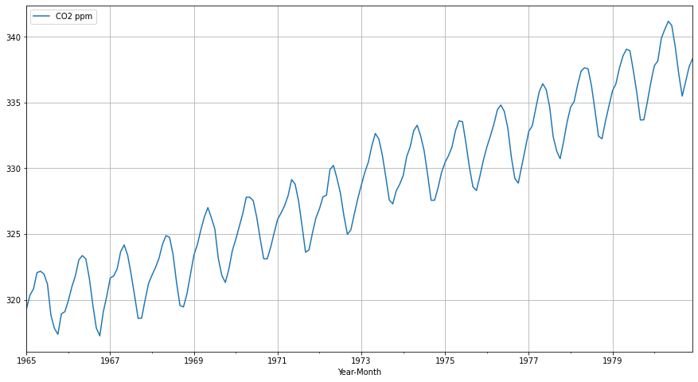

```python
df.plot();
plt.grid()
```

# Plot a boxplot to understand the variation of Carbon Dioxide in parts per million with respect to months across years.

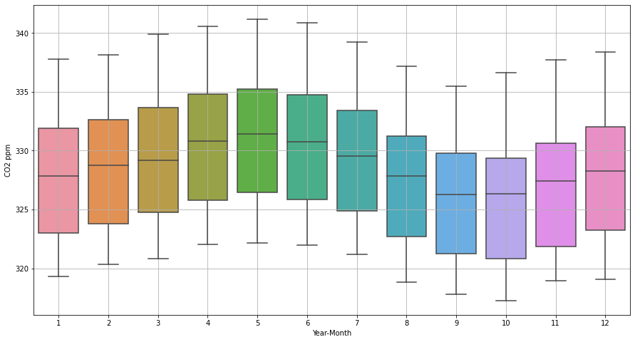

```python
sns.boxplot(x=df.index.month,y=df['CO2 ppm'])
plt.grid();
```

# Plot a boxplot to understand the variation of Carbon Dioxide in parts per million across years.

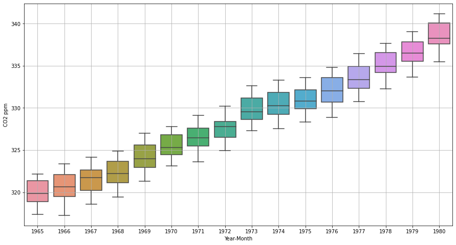

```python
sns.boxplot(x=df.index.year,y=df['CO2 ppm'])
plt.grid();
```

# Plot a graph of monthly Carbon Dioxide in parts per million across years.

```python
monthly_co2ppm_across_years = pd.pivot_table(df, values = 'CO2 ppm', columns = df.index.month_name(), index = df.index.year)
monthly_co2ppm_across_years
```

| Year-Month | April | August | December | February | January | July | June | March | May | November | October | September |
| --- | --- | --- | --- | --- | --- | --- | --- | --- | --- | --- | --- | --- |
| 1965 | 322.06 | 318.81 | 319.09 | 320.36 | 319.32 | 321.20 | 321.95 | 320.82 | 322.17 | 318.93 | 317.37 | 317.82 |
| 1966 | 323.03 | 319.64 | 320.26 | 320.98 | 319.94 | 321.65 | 323.11 | 321.81 | 323.36 | 319.06 | 317.25 | 317.86 |
| 1967 | 323.67 | 320.29 | 321.25 | 321.81 | 321.65 | 321.93 | 323.39 | 322.36 | 324.17 | 319.98 | 318.60 | 318.58 |
| 1968 | 324.23 | 321.34 | 321.92 | 322.47 | 321.88 | 323.47 | 324.75 | 323.17 | 324.88 | 320.45 | 319.45 | 319.56 |
| 1969 | 326.31 | 323.12 | 323.72 | 324.21 | 323.40 | 325.37 | 326.24 | 325.33 | 327.01 | 322.31 | 321.31 | 321.85 |
| 1970 | 327.80 | 324.63 | 325.09 | 325.57 | 324.60 | 326.28 | 327.54 | 326.55 | 327.80 | 323.99 | 323.11 | 323.12 |
| 1971 | 327.92 | 325.62 | 326.25 | 326.61 | 326.12 | 327.52 | 328.80 | 327.16 | 329.14 | 325.10 | 323.80 | 323.61 |
| 1972 | 329.91 | 326.39 | 327.71 | 327.83 | 326.93 | 328.11 | 329.25 | 327.95 | 330.22 | 326.54 | 325.32 | 324.97 |
| 1973 | 331.69 | 329.36 | 328.79 | 329.69 | 328.73 | 331.03 | 332.24 | 330.47 | 332.65 | 328.28 | 327.29 | 327.60 |
| 1974 | 332.85 | 329.53 | 329.69 | 330.89 | 329.45 | 331.34 | 332.47 | 331.63 | 333.28 | 328.53 | 327.57 | 327.57 |
| 1975 | 332.87 | 330.05 | 330.63 | 330.97 | 330.45 | 331.90 | 333.55 | 331.64 | 333.61 | 329.41 | 328.31 | 328.58 |
| 1976 | 334.45 | 330.87 | 331.50 | 332.46 | 331.63 | 333.05 | 334.32 | 333.36 | 334.82 | 330.18 | 328.87 | 329.24 |
| 1977 | 335.82 | 332.41 | 333.53 | 333.23 | 332.81 | 334.65 | 335.99 | 334.55 | 336.44 | 332.05 | 330.73 | 331.32 |
| 1978 | 337.39 | 334.39 | 334.76 | 335.07 | 334.66 | 336.25 | 337.57 | 336.33 | 337.65 | 333.59 | 332.25 | 332.44 |
| 1979 | 338.54 | 335.71 | 336.53 | 336.44 | 335.89 | 337.41 | 338.95 | 337.63 | 339.06 | 335.05 | 333.69 | 333.68 |
| 1980 | 340.57 | 337.19 | 338.36 | 338.16 | 337.81 | 339.25 | 340.87 | 339.88 | 341.19 | 337.74 | 336.63 | 335.49 |

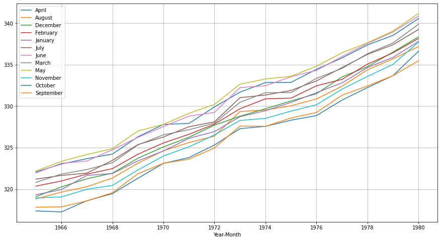

```python
monthly_co2ppm_across_years.plot()
plt.grid()
plt.legend(loc='best');
```

# Decompose the Time Series to understand the various components.

```python
from statsmodels.tsa.seasonal import seasonal_decompose
```

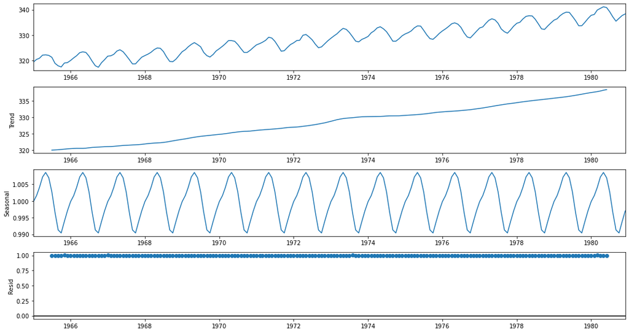

```python
decomposition = seasonal_decompose(df,model='multiplicative')
decomposition.plot();
```

# Plot a graph of the average and percentage change of Carbon Dioxide in parts per million across years.

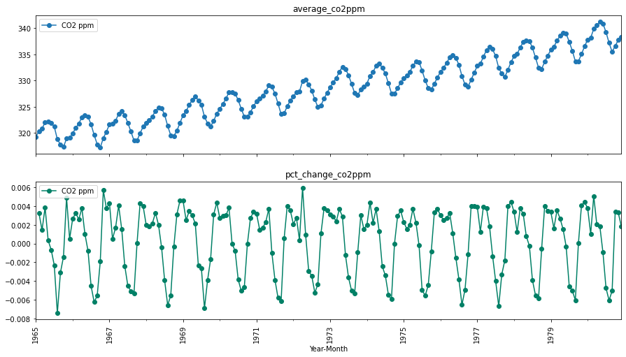

```python
# group by date and get average Customers, and precent change
average_co2ppm    = df.groupby(df.index)["CO2 ppm"].mean()
pct_change_co2ppm = df.groupby(df.index)["CO2 ppm"].sum().pct_change()

fig, (axis1,axis2) = plt.subplots(2,1,sharex=True,figsize=(15,8))

# plot average CO2-ppm over time(year-month)
ax1 = average_co2ppm.plot(legend=True,ax=axis1,marker='o',title="average_co2ppm")

ax1.set_xticks(range(len(average_co2ppm)))
ax1.set_xticklabels(average_co2ppm.index.tolist(), rotation=90)

# plot precent change for CO2-ppm over time(year-month)
ax2 = pct_change_co2ppm.plot(legend=True,ax=axis2,marker='o',rot=90,colormap="summer",title="pct_change_co2ppm")
```

# Split the data into train and test. The first 75% of the data should be in training and last 25% of the data should be in test

```python
train    =   df[0:int(len(df)*0.75)]
test     =   df[int(len(df)*0.75):]
```

```python
print(train.head(),'\n')
print(train.tail(),'\n\n')
print(test.head(),'\n')
print(test.tail(),'\n')
```

```
            CO2 ppm
Year-Month
1965-01-01   319.32
1965-02-01   320.36
1965-03-01   320.82
1965-04-01   322.06
1965-05-01   322.17

            CO2 ppm
Year-Month
1976-08-01   330.87
1976-09-01   329.24
1976-10-01   328.87
1976-11-01   330.18
1976-12-01   331.50


            CO2 ppm
Year-Month
1977-01-01   332.81
1977-02-01   333.23
1977-03-01   334.55
1977-04-01   335.82
1977-05-01   336.44

            CO2 ppm
Year-Month
1980-08-01   337.19
1980-09-01   335.49
1980-10-01   336.63
1980-11-01   337.74
1980-12-01   338.36
```

# Test the training data for stationarity using the Augmented Dickey-Fuller (ADF) test at $\alpha$ = 0.05.

# If the data is non-stationary, use appropriate measures to stationarize the data and then check for stationarity using the Augmented Dickey-Fuller (ADF) Test at $\alpha$ = 0.05.

```python
## Test for stationarity of the series - Dicky Fuller test

from statsmodels.tsa.stattools import adfuller
def test_stationarity(timeseries):

    #Determing rolling statistics
    rolmean = timeseries.rolling(window=7).mean()
    rolstd = timeseries.rolling(window=7).std()

    #Plot rolling statistics:
    orig = plt.plot(timeseries, color='blue',label='Original')
    mean = plt.plot(rolmean, color='red', label='Rolling Mean')
    std = plt.plot(rolstd, color='black', label = 'Rolling Std')
    plt.legend(loc='best')
    plt.title('Rolling Mean & Standard Deviation')
    plt.show(block=False)

    #Perform Dickey-Fuller test:
    print ('Results of Dickey-Fuller Test:')
    dftest = adfuller(timeseries, autolag='AIC')
    dfoutput = pd.Series(dftest[0:4], index=['Test Statistic','p-value','#Lags Used','Number of Observations Used'])
    for key,value in dftest[4].items():
        dfoutput['Critical Value (%s)'%key] = value
    print (dfoutput,'\n')
```

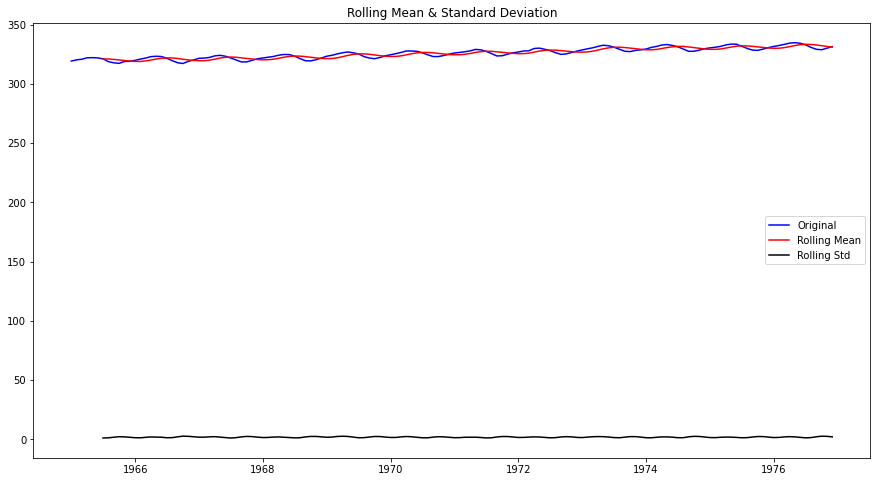

```
Results of Dickey-Fuller Test:
Test Statistic                  -0.257683
p-value                          0.931288
#Lags Used                      13.000000
Number of Observations Used    130.000000
Critical Value (1%)             -3.481682
Critical Value (5%)             -2.884042
Critical Value (10%)            -2.578770
dtype: float64
```

```python
test_stationarity(train['CO2 ppm'])
```

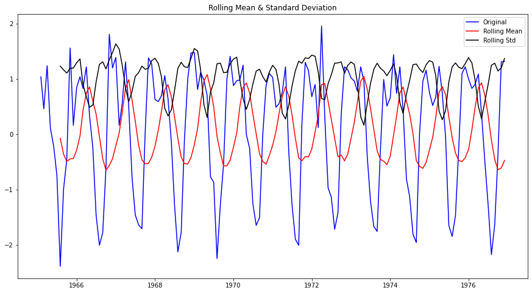

```
Results of Dickey-Fuller Test:
Test Statistic                  -3.386995
p-value                          0.011410
#Lags Used                      12.000000
Number of Observations Used    130.000000
Critical Value (1%)             -3.481682
Critical Value (5%)             -2.884042
Critical Value (10%)            -2.578770
dtype: float64
```

```python
test_stationarity(train.diff().dropna())
```

##### Going forward, for all the questions 'training data' means the data on which the model will be built and which is stationary in nature.

# Check the ACF and PACF of the training data.

```python
train_diff = train.diff(periods=1).dropna()
train_diff
```

| Year-Month | CO2 ppm |
| --- | --- |
| 1965-02-01 | 1.04 |
| 1965-03-01 | 0.46 |
| 1965-04-01 | 1.24 |
| 1965-05-01 | 0.11 |
| 1965-06-01 | -0.22 |
| ... | ... |
| 1976-08-01 | -2.18 |
| 1976-09-01 | -1.63 |
| 1976-10-01 | -0.37 |
| 1976-11-01 | 1.31 |
| 1976-12-01 | 1.32 |

143 rows × 1 columns

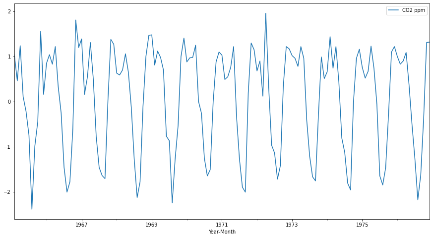

```python
train_diff.plot();
```

```python
from statsmodels.graphics.tsaplots import plot_acf, plot_pacf
```

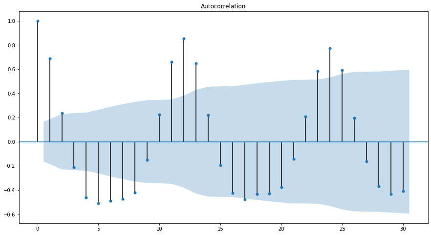

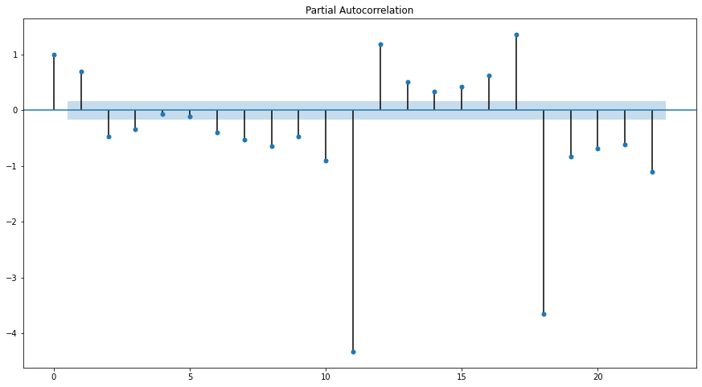

```python
plot_acf(train_diff,lags=30)
plot_pacf(train_diff);
```

# Build an Automated version of an ARIMA model on the training data for which the best parameters are selected in accordance with the lowest Akaike Information Criteria (AIC).

[Here we have taken the range of values of p and q to be between 0 and 2]

```python
## The following loop helps us in getting a combination of different parameters of p and q in the range of 0 and 2
## We have kept the value of d as 0 as we have already taken a difference of the series to make it stationary.

import itertools
p = q = range(0, 3)
d= range(1,2)
pdq = list(itertools.product(p, d, q))
print('Some parameter combinations for the Model...')
for i in range(1,len(pdq)):
    print('Model: {}'.format(pdq[i]))
```

```
Some parameter combinations for the Model...
Model: (0, 1, 1)
Model: (0, 1, 2)
Model: (1, 1, 0)
Model: (1, 1, 1)
Model: (1, 1, 2)
Model: (2, 1, 0)
Model: (2, 1, 1)
Model: (2, 1, 2)
```

```python
# Creating an empty Dataframe with column names only
ARIMA_AIC = pd.DataFrame(columns=['param', 'AIC'])
ARIMA_AIC
```

|  | param | AIC |
| --- | --- | --- |

```python
from statsmodels.tsa.arima.model import ARIMA

for param in pdq:
    ARIMA_model = ARIMA(train['CO2 ppm'].values,order=param).fit()
    print('ARIMA{} - AIC:{}'.format(param,ARIMA_model.aic))
    ARIMA_AIC = ARIMA_AIC.append({'param':param, 'AIC': ARIMA_model.aic}, ignore_index=True)
```

```
ARIMA(0, 1, 0) - AIC:444.71223526799133
ARIMA(0, 1, 1) - AIC:363.92339612677347
ARIMA(0, 1, 2) - AIC:333.39295242257583
ARIMA(1, 1, 0) - AIC:352.7724961824192
ARIMA(1, 1, 1) - AIC:338.10742392857657
ARIMA(1, 1, 2) - AIC:327.25243019817447
ARIMA(2, 1, 0) - AIC:320.97281967587423
ARIMA(2, 1, 1) - AIC:285.0008293109328
ARIMA(2, 1, 2) - AIC:286.520013008227
```

```python
## Sort the above AIC values in the ascending order to get the parameters for the minimum AIC value

ARIMA_AIC.sort_values(by='AIC',ascending=True)
```

|  | param | AIC |
| --- | --- | --- |
| 7 | (2, 1, 1) | 285.000829 |
| 8 | (2, 1, 2) | 286.520013 |
| 6 | (2, 1, 0) | 320.972820 |
| 5 | (1, 1, 2) | 327.252430 |
| 2 | (0, 1, 2) | 333.392952 |
| 4 | (1, 1, 1) | 338.107424 |
| 3 | (1, 1, 0) | 352.772496 |
| 1 | (0, 1, 1) | 363.923396 |
| 0 | (0, 1, 0) | 444.712235 |

```python
mod = ARIMA(train['CO2 ppm'], order=(2,1,1))

results_Arima = mod.fit()

print(results_Arima.summary())
```

```
                               SARIMAX Results
==============================================================================
Dep. Variable:                CO2 ppm   No. Observations:                  144
Model:                 ARIMA(2, 1, 1)   Log Likelihood                -138.500
Date:                Thu, 25 Jun 2020   AIC                            285.001
Time:                        18:06:02   BIC                            296.852
Sample:                    01-01-1965   HQIC                           289.817
                         - 12-01-1976
Covariance Type:                  opg
==============================================================================
                 coef    std err          z      P>|z|      [0.025      0.975]
------------------------------------------------------------------------------
ar.L1          1.5291      0.054     28.213      0.000       1.423       1.635
ar.L2         -0.8274      0.054    -15.320      0.000      -0.933      -0.722
ma.L1         -0.8291      0.066    -12.484      0.000      -0.959      -0.699
sigma2         0.3998      0.044      9.166      0.000       0.314       0.485
===================================================================================
Ljung-Box (Q):                      273.22   Jarque-Bera (JB):                 2.02
Prob(Q):                              0.00   Prob(JB):                         0.37
Heteroskedasticity (H):               0.65   Skew:                             0.20
Prob(H) (two-sided):                  0.14   Kurtosis:                         3.43
===================================================================================

Warnings:
[1] Covariance matrix calculated using the outer product of gradients (complex-step).
```

The above model is an AutoRegressive Integrated Moving Average model of order (2,1,1) i.e. the Time Series being regressed upon itself at a lag of 2, the errors from a lag of 1 and a lag and a degree or order differencing of 1 to make it stationary.

# Predict on the Test Set using this model and evaluate the model on the test set using RMSE and MAPE

```python
## Mean Absolute Percentage - Function Definition

def MAPE(y, yhat):
    y, yhat = np.array(y), np.array(yhat)
    try:
        mape =  round(np.sum(np.abs(yhat - y)) / np.sum(y) * 100,2)
    except:
        print("Observed values are empty")
        mape = np.nan
    return mape
```

```python
from sklearn.metrics import mean_squared_error
```

```python
predicted_autoARIMA = results_Arima.forecast(steps=len(test))
predicted_autoARIMA
```

```
1977-01-01    332.717760
1977-02-01    333.487603
1977-03-01    333.657146
1977-04-01    333.279400
1977-05-01    332.561515
1977-06-01    331.776372
1977-07-01    331.169825
1977-08-01    330.892019
1977-09-01    330.969104
1977-10-01    331.316837
1977-11-01    331.784765
1977-12-01    332.212538
1978-01-01    332.479460
1978-02-01    332.533652
1978-03-01    332.395659
1978-04-01    332.139816
1978-05-01    331.862793
1978-06-01    331.650894
1978-07-01    331.556102
1978-08-01    331.586488
1978-09-01    331.711384
1978-10-01    331.877217
1978-11-01    332.027446
1978-12-01    332.119943
1979-01-01    332.137074
1979-02-01    332.086734
1979-03-01    331.995587
1979-04-01    331.897868
1979-05-01    331.823866
1979-06-01    331.791566
1979-07-01    331.803409
1979-08-01    331.848244
1979-09-01    331.906999
1979-10-01    331.959744
1979-11-01    331.991779
1979-12-01    331.997120
1980-01-01    331.978781
1980-02-01    331.946319
1980-03-01    331.911857
1980-04-01    331.886022
1980-05-01    331.875033
1980-06-01    331.879606
1980-07-01    331.895692
1980-08-01    331.916504
1980-09-01    331.935018
1980-10-01    331.946106
1980-11-01    331.947742
1980-12-01    331.941069
Freq: MS, dtype: float64
```

```python
results_Arima.predict(start=pd.to_datetime('1977-01-01'),end=pd.to_datetime('1980-12-01 '),typ = 'level',dynamic=True,full_results=True)
```

```
1977-01-01    332.717760
1977-02-01    333.487603
1977-03-01    333.657146
1977-04-01    333.279400
1977-05-01    332.561515
1977-06-01    331.776372
1977-07-01    331.169825
1977-08-01    330.892019
1977-09-01    330.969104
1977-10-01    331.316837
1977-11-01    331.784765
1977-12-01    332.212538
1978-01-01    332.479460
1978-02-01    332.533652
1978-03-01    332.395659
1978-04-01    332.139816
1978-05-01    331.862793
1978-06-01    331.650894
1978-07-01    331.556102
1978-08-01    331.586488
1978-09-01    331.711384
1978-10-01    331.877217
1978-11-01    332.027446
1978-12-01    332.119943
1979-01-01    332.137074
1979-02-01    332.086734
1979-03-01    331.995587
1979-04-01    331.897868
1979-05-01    331.823866
1979-06-01    331.791566
1979-07-01    331.803409
1979-08-01    331.848244
1979-09-01    331.906999
1979-10-01    331.959744
1979-11-01    331.991779
1979-12-01    331.997120
1980-01-01    331.978781
1980-02-01    331.946319
1980-03-01    331.911857
1980-04-01    331.886022
1980-05-01    331.875033
1980-06-01    331.879606
1980-07-01    331.895692
1980-08-01    331.916504
1980-09-01    331.935018
1980-10-01    331.946106
1980-11-01    331.947742
1980-12-01    331.941069
Freq: MS, dtype: float64
```

```python
RMSE_autoARIMA = mean_squared_error(test['CO2 ppm'],predicted_autoARIMA,squared=False)
MAPE_autoARIMA = MAPE(test['CO2 ppm'],predicted_autoARIMA)

print('RMSE for the autofit ARIMA model:',RMSE_autoARIMA,'\nMAPE for the autofit ARIMA model:',MAPE_autoARIMA)
```

```
RMSE for the autofit ARIMA model: 4.753883498881171
MAPE for the autofit ARIMA model: 1.2
```

```python
resultsDf = pd.DataFrame({'RMSE': [RMSE_autoARIMA],'MAPE':[MAPE_autoARIMA]}
                           ,index=['ARIMA(2,1,1)'])

resultsDf
```

|  | RMSE | MAPE |
| --- | --- | --- |
| ARIMA(2,1,1) | 4.753883 | 1.2 |

# Check for stationarity on the whole data and stationarize the data if needed. Build a model on the whole data using the parameters got from best fit (with respect to the lowest AIC value) ARIMA model.

### Note: Stationarity is to be checked with the Augmented Dickey-Fuller (ADF) test at $\alpha$ = 0.05.

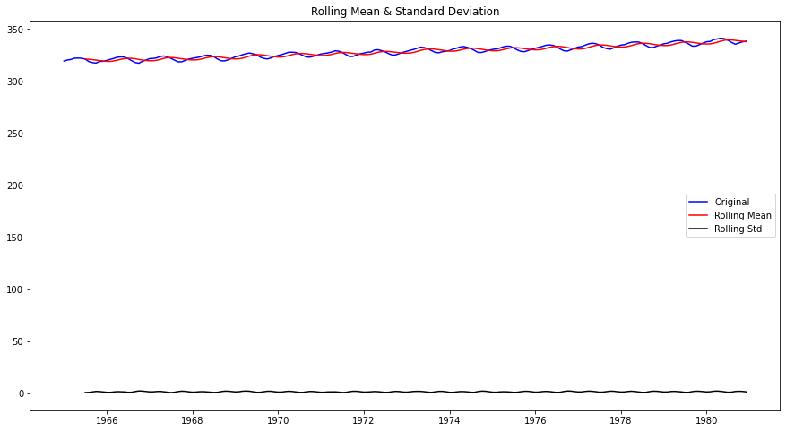

```
Results of Dickey-Fuller Test:
Test Statistic                   1.269677
p-value                          0.996434
#Lags Used                      12.000000
Number of Observations Used    179.000000
Critical Value (1%)             -3.467420
Critical Value (5%)             -2.877826
Critical Value (10%)            -2.575452
dtype: float64
```

```python
test_stationarity(df['CO2 ppm'])
```

We see that the data is not stationary. We will go ahead and take appropriate levels of differencing to make the data stationary.

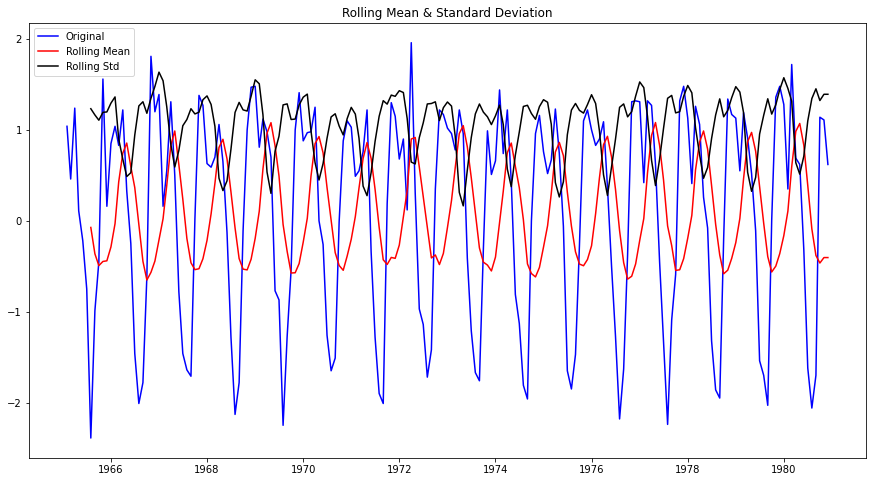

```
Results of Dickey-Fuller Test:
Test Statistic                  -4.750107
p-value                          0.000068
#Lags Used                      11.000000
Number of Observations Used    179.000000
Critical Value (1%)             -3.467420
Critical Value (5%)             -2.877826
Critical Value (10%)            -2.575452
dtype: float64
```

```python
test_stationarity(df['CO2 ppm'].diff().dropna())
```

We notice that the data is stationary using an Augmented Dickey-Fuller test after taking a differencing of order 1.

```python
#Building the model
full_model_autoARIMA = ARIMA(df['CO2 ppm'], order=(2,1,1))

results_Arima_full_model = full_model_autoARIMA.fit()

print(results_Arima_full_model.summary())
```

```
                               SARIMAX Results
==============================================================================
Dep. Variable:                CO2 ppm   No. Observations:                  192
Model:                 ARIMA(2, 1, 1)   Log Likelihood                -190.652
Date:                Thu, 25 Jun 2020   AIC                            389.305
Time:                        18:07:02   BIC                            402.314
Sample:                    01-01-1965   HQIC                           394.574
                         - 12-01-1980
Covariance Type:                  opg
==============================================================================
                 coef    std err          z      P>|z|      [0.025      0.975]
------------------------------------------------------------------------------
ar.L1          1.5236      0.047     32.128      0.000       1.431       1.617
ar.L2         -0.8195      0.051    -16.209      0.000      -0.919      -0.720
ma.L1         -0.8203      0.061    -13.461      0.000      -0.940      -0.701
sigma2         0.4262      0.040     10.677      0.000       0.348       0.504
===================================================================================
Ljung-Box (Q):                      378.42   Jarque-Bera (JB):                 5.58
Prob(Q):                              0.00   Prob(JB):                         0.06
Heteroskedasticity (H):               0.96   Skew:                             0.39
Prob(H) (two-sided):                  0.87   Kurtosis:                         3.32
===================================================================================

Warnings:
[1] Covariance matrix calculated using the outer product of gradients (complex-step).
```

# Forecast the values for the next 24 months using the ARIMA model just built and plot them along with confidence intervals. Also, plot the existing time series data in this graph.

```python
pred_dynamic = results_Arima_full_model.get_prediction(start=pd.to_datetime('1981-01-01'), dynamic=True, full_results=True)
```

```python
pred_dynamic_ci = pred_dynamic.conf_int()
```

```python
pred95 = results_Arima_full_model.get_forecast(steps=24, alpha=0.05)
pred_ci_95 = pred95.conf_int()
```

```python
forecast_fullmodel_autoarima = pred95.predicted_mean
```

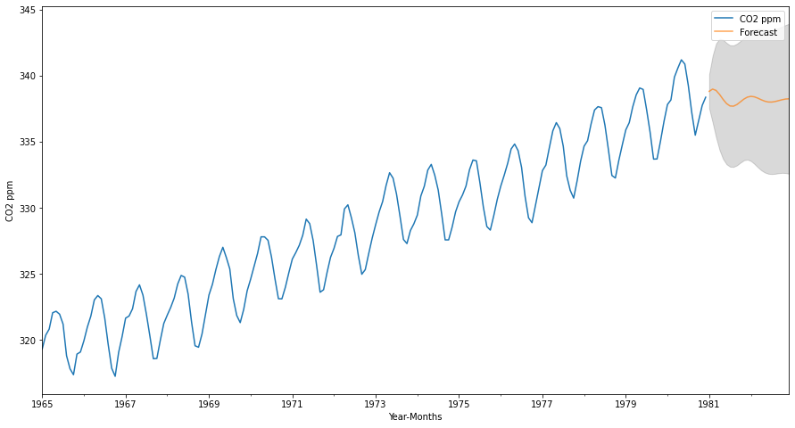

```python
# plot the forecast along with the confidence band

axis = df.plot(label='Observed', figsize=(15, 8))
forecast_fullmodel_autoarima.plot(ax=axis, label='Forecast', alpha=0.7)
axis.fill_between(forecast_fullmodel_autoarima.index, pred_ci_95['lower CO2 ppm'], pred_ci_95['upper CO2 ppm'], color='k', alpha=.15)
axis.set_xlabel('Year-Months')
axis.set_ylabel('CO2 ppm')
plt.legend(loc='best')
plt.show()
```

For a ARIMA model, we can see the predictions with 95% confidence interval bands. The seasonality was unable to be captured. Let us try out a SARIMA model.

# Build an Automated version of an SARIMA model on the training data for which the best parameters are selected in accordance with the lowest Akaike Information Criteria (AIC).

[Here we have taken the range of values of p,q,P and Q to be between 0 and 2]

```python
import itertools
p = q = range(0, 3)
d= range(1,2)
D = range(0,1)
pdq = list(itertools.product(p, d, q))
model_pdq = [(x[0], x[1], x[2], 12) for x in list(itertools.product(p, D, q))]
print('Examples of some parameter combinations for Model...')
for i in range(1,len(pdq)):
    print('Model: {}{}'.format(pdq[i], model_pdq[i]))
```

```
Examples of some parameter combinations for Model...
Model: (0, 1, 1)(0, 0, 1, 12)
Model: (0, 1, 2)(0, 0, 2, 12)
Model: (1, 1, 0)(1, 0, 0, 12)
Model: (1, 1, 1)(1, 0, 1, 12)
Model: (1, 1, 2)(1, 0, 2, 12)
Model: (2, 1, 0)(2, 0, 0, 12)
Model: (2, 1, 1)(2, 0, 1, 12)
Model: (2, 1, 2)(2, 0, 2, 12)
```

```python
SARIMA_AIC = pd.DataFrame(columns=['param','seasonal', 'AIC'])
SARIMA_AIC
```

|  | param | seasonal | AIC |
| --- | --- | --- | --- |

```python
import statsmodels.api as sm

for param in pdq:
    for param_seasonal in model_pdq:
        SARIMA_model = sm.tsa.statespace.SARIMAX(train['CO2 ppm'].values,
                                            order=param,
                                            seasonal_order=param_seasonal,
                                            enforce_stationarity=False,
                                            enforce_invertibility=False)

        results_SARIMA = SARIMA_model.fit(maxiter=1000)
        print('SARIMA{}x{}7 - AIC:{}'.format(param, param_seasonal, results_SARIMA.aic))
        SARIMA_AIC = SARIMA_AIC.append({'param':param,'seasonal':param_seasonal ,'AIC': results_SARIMA.aic}, ignore_index=True)
```

```
SARIMA(0, 1, 0)x(0, 0, 0, 12)7 - AIC:441.78062205228593
SARIMA(0, 1, 0)x(0, 0, 1, 12)7 - AIC:322.9968747866851
SARIMA(0, 1, 0)x(0, 0, 2, 12)7 - AIC:232.00849360943687
SARIMA(0, 1, 0)x(1, 0, 0, 12)7 - AIC:151.72863151941152
SARIMA(0, 1, 0)x(1, 0, 1, 12)7 - AIC:90.95070210731063
SARIMA(0, 1, 0)x(1, 0, 2, 12)7 - AIC:62.41395747447282
SARIMA(0, 1, 0)x(2, 0, 0, 12)7 - AIC:93.02503213188734
```

```
SARIMA(0, 1, 0)x(2, 0, 1, 12)7 - AIC:66.07400537770857
SARIMA(0, 1, 0)x(2, 0, 2, 12)7 - AIC:62.9105800083774
SARIMA(0, 1, 1)x(0, 0, 0, 12)7 - AIC:358.6597354199836
SARIMA(0, 1, 1)x(0, 0, 1, 12)7 - AIC:284.8604635313625
SARIMA(0, 1, 1)x(0, 0, 2, 12)7 - AIC:209.13648708967102
SARIMA(0, 1, 1)x(1, 0, 0, 12)7 - AIC:151.7343684540478
SARIMA(0, 1, 1)x(1, 0, 1, 12)7 - AIC:84.83368696578304
SARIMA(0, 1, 1)x(1, 0, 2, 12)7 - AIC:65.43056349934974
SARIMA(0, 1, 1)x(2, 0, 0, 12)7 - AIC:92.63486091245893
SARIMA(0, 1, 1)x(2, 0, 1, 12)7 - AIC:63.53525660718632
SARIMA(0, 1, 1)x(2, 0, 2, 12)7 - AIC:63.87633730143067
SARIMA(0, 1, 2)x(0, 0, 0, 12)7 - AIC:325.10050933004203
SARIMA(0, 1, 2)x(0, 0, 1, 12)7 - AIC:260.00544503783453
SARIMA(0, 1, 2)x(0, 0, 2, 12)7 - AIC:195.26839010084237
SARIMA(0, 1, 2)x(1, 0, 0, 12)7 - AIC:152.6363576009623
SARIMA(0, 1, 2)x(1, 0, 1, 12)7 - AIC:86.70658440277336
SARIMA(0, 1, 2)x(1, 0, 2, 12)7 - AIC:67.92001517815669
SARIMA(0, 1, 2)x(2, 0, 0, 12)7 - AIC:94.52730029467365
SARIMA(0, 1, 2)x(2, 0, 1, 12)7 - AIC:65.30062271724978
SARIMA(0, 1, 2)x(2, 0, 2, 12)7 - AIC:66.61318355274958
SARIMA(1, 1, 0)x(0, 0, 0, 12)7 - AIC:349.8409683858839
SARIMA(1, 1, 0)x(0, 0, 1, 12)7 - AIC:274.7339406709095
SARIMA(1, 1, 0)x(0, 0, 2, 12)7 - AIC:203.31196749001657
SARIMA(1, 1, 0)x(1, 0, 0, 12)7 - AIC:151.80396965955333
SARIMA(1, 1, 0)x(1, 0, 1, 12)7 - AIC:85.92341339961243
SARIMA(1, 1, 0)x(1, 0, 2, 12)7 - AIC:62.004003135447086
SARIMA(1, 1, 0)x(2, 0, 0, 12)7 - AIC:86.92115649607184
SARIMA(1, 1, 0)x(2, 0, 1, 12)7 - AIC:63.434247373461304
SARIMA(1, 1, 0)x(2, 0, 2, 12)7 - AIC:64.09037413866004
SARIMA(1, 1, 1)x(0, 0, 0, 12)7 - AIC:333.4006501474978
SARIMA(1, 1, 1)x(0, 0, 1, 12)7 - AIC:269.6307351856565
SARIMA(1, 1, 1)x(0, 0, 2, 12)7 - AIC:202.99247357437892
SARIMA(1, 1, 1)x(1, 0, 0, 12)7 - AIC:146.1316078897092
SARIMA(1, 1, 1)x(1, 0, 1, 12)7 - AIC:85.29404829277419
SARIMA(1, 1, 1)x(1, 0, 2, 12)7 - AIC:66.03407475969522
SARIMA(1, 1, 1)x(2, 0, 0, 12)7 - AIC:88.5445893963487
SARIMA(1, 1, 1)x(2, 0, 1, 12)7 - AIC:64.64513944138304
SARIMA(1, 1, 1)x(2, 0, 2, 12)7 - AIC:64.50812917123773
SARIMA(1, 1, 2)x(0, 0, 0, 12)7 - AIC:320.1485060346621
SARIMA(1, 1, 2)x(0, 0, 1, 12)7 - AIC:257.15917476441587
```

[output cut: 19 more lines]

```
SARIMA(2, 1, 1)x(1, 0, 0, 12)7 - AIC:147.02442713675035
SARIMA(2, 1, 1)x(1, 0, 1, 12)7 - AIC:87.52231228896953
SARIMA(2, 1, 1)x(1, 0, 2, 12)7 - AIC:68.03120938499092
SARIMA(2, 1, 1)x(2, 0, 0, 12)7 - AIC:90.40462497444209
SARIMA(2, 1, 1)x(2, 0, 1, 12)7 - AIC:66.31243646862406
SARIMA(2, 1, 1)x(2, 0, 2, 12)7 - AIC:67.96398803453326
SARIMA(2, 1, 2)x(0, 0, 0, 12)7 - AIC:278.41928636751294
SARIMA(2, 1, 2)x(0, 0, 1, 12)7 - AIC:202.60542477537842
SARIMA(2, 1, 2)x(0, 0, 2, 12)7 - AIC:158.20849475914756
SARIMA(2, 1, 2)x(1, 0, 0, 12)7 - AIC:148.70866385931285
SARIMA(2, 1, 2)x(1, 0, 1, 12)7 - AIC:87.80883012128773
SARIMA(2, 1, 2)x(1, 0, 2, 12)7 - AIC:69.48313800010487
SARIMA(2, 1, 2)x(2, 0, 0, 12)7 - AIC:91.13269254531872
SARIMA(2, 1, 2)x(2, 0, 1, 12)7 - AIC:68.39385478680931
SARIMA(2, 1, 2)x(2, 0, 2, 12)7 - AIC:68.32887760048149
```

```python
SARIMA_AIC.sort_values(by=['AIC']).head()
```

|  | param | seasonal | AIC |
| --- | --- | --- | --- |
| 32 | (1, 1, 0) | (1, 0, 2, 12) | 62.004003 |
| 5 | (0, 1, 0) | (1, 0, 2, 12) | 62.413957 |
| 8 | (0, 1, 0) | (2, 0, 2, 12) | 62.910580 |
| 34 | (1, 1, 0) | (2, 0, 1, 12) | 63.434247 |
| 16 | (0, 1, 1) | (2, 0, 1, 12) | 63.535257 |

```python
import statsmodels.api as sm

mod = sm.tsa.statespace.SARIMAX(train['CO2 ppm'],
                                order=(1,1,0),
                                seasonal_order=(1, 0, 2, 12),
                                enforce_stationarity=False,
                                enforce_invertibility=False)
results_SARIMA = mod.fit()
print(results_SARIMA.summary())
```

```
                                        SARIMAX Results
===============================================================================================
Dep. Variable:                                 CO2 ppm   No. Observations:                  144
Model:             SARIMAX(1, 1, 0)x(1, 0, [1, 2], 12)   Log Likelihood                 -26.002
Date:                                 Thu, 25 Jun 2020   AIC                             62.004
Time:                                         18:09:06   BIC                             75.857
Sample:                                     01-01-1965   HQIC                            67.629
                                          - 12-01-1976
Covariance Type:                                   opg
==============================================================================
                 coef    std err          z      P>|z|      [0.025      0.975]
------------------------------------------------------------------------------
ar.L1         -0.1409      0.096     -1.466      0.143      -0.329       0.047
ar.S.L12       0.9938      0.007    150.730      0.000       0.981       1.007
ma.S.L12      -1.1336    465.212     -0.002      0.998    -912.933     910.666
ma.S.L24       0.1335     62.215      0.002      0.998    -121.805     122.072
sigma2         0.0699     32.500      0.002      0.998     -63.630      63.769
===================================================================================
Ljung-Box (Q):                       38.28   Jarque-Bera (JB):                 0.04
Prob(Q):                              0.55   Prob(JB):                         0.98
Heteroskedasticity (H):               0.87   Skew:                             0.04
Prob(H) (two-sided):                  0.67   Kurtosis:                         3.03
===================================================================================

Warnings:
[1] Covariance matrix calculated using the outer product of gradients (complex-step).
```

# Predict on the Test Set using this model and evaluate the model on the test set using RMSE and MAPE

```python
predicted_autoSARIMA = results_SARIMA.forecast(steps=len(test))
predicted_autoSARIMA
```

```
1977-01-01    332.381548
1977-02-01    333.136754
1977-03-01    333.801930
1977-04-01    334.976757
1977-05-01    335.545633
1977-06-01    335.078717
1977-07-01    333.867768
1977-08-01    332.097325
1977-09-01    330.496922
1977-10-01    330.391972
1977-11-01    331.495487
1977-12-01    332.606047
1978-01-01    333.518580
1978-02-01    334.271171
1978-03-01    334.959314
1978-04-01    336.116899
1978-05-01    336.661312
1978-06-01    336.199471
1978-07-01    334.983837
1978-08-01    333.177744
1978-09-01    331.586615
1978-10-01    331.449617
1978-11-01    332.568581
1978-12-01    333.696872
1979-01-01    334.600280
1979-02-01    335.348694
1979-03-01    336.032503
1979-04-01    337.182922
1979-05-01    337.723959
1979-06-01    337.264981
1979-07-01    336.056883
1979-08-01    334.261985
1979-09-01    332.680719
1979-10-01    332.544570
1979-11-01    333.656598
1979-12-01    334.777895
1980-01-01    335.675703
1980-02-01    336.419478
1980-03-01    337.099049
1980-04-01    338.242336
1980-05-01    338.780019
1980-06-01    338.323886
1980-07-01    337.123277
1980-08-01    335.339505
1980-09-01    333.768041
1980-10-01    333.632736
1980-11-01    334.737871
1980-12-01    335.852217
Freq: MS, dtype: float64
```

```python
RMSE_autoSARIMA = mean_squared_error(test['CO2 ppm'],predicted_autoSARIMA,squared=False)
MAPE_autoSARIMA = MAPE(test['CO2 ppm'],predicted_autoSARIMA)

print('RMSE for the autofit SARIMA model:',RMSE_autoSARIMA,'\nMAPE for the autofit SARIMA model:',MAPE_autoSARIMA)
```

```
RMSE for the autofit SARIMA model: 1.5276216785438943
MAPE for the autofit SARIMA model: 0.41
```

```python
temp_resultsDf = pd.DataFrame({'RMSE': [RMSE_autoSARIMA],'MAPE':[MAPE_autoSARIMA]}
                           ,index=['SARIMA(1, 1, 0)(1,0,2)12'])

resultsDf = pd.concat([resultsDf, temp_resultsDf])
resultsDf
```

|  | RMSE | MAPE |
| --- | --- | --- |
| ARIMA(2,1,1) | 4.753883 | 1.20 |
| SARIMA(1, 1, 0)(1,0,2)12 | 1.527622 | 0.41 |

# Build a model on the whole data using the parameters got from best fit (with respect to the lowest AIC value) SARIMA model.

```python
import statsmodels.api as sm

mod = sm.tsa.statespace.SARIMAX(df['CO2 ppm'],
                                order=(1,1,0),
                                seasonal_order=(1, 0, 2, 12),
                                enforce_stationarity=False,
                                enforce_invertibility=False)
results_SARIMA_fullmodel = mod.fit()
print(results_SARIMA_fullmodel.summary())
```

```
                                        SARIMAX Results
===============================================================================================
Dep. Variable:                                 CO2 ppm   No. Observations:                  192
Model:             SARIMAX(1, 1, 0)x(1, 0, [1, 2], 12)   Log Likelihood                 -45.995
Date:                                 Thu, 25 Jun 2020   AIC                            101.990
Time:                                         18:09:44   BIC                            117.550
Sample:                                     01-01-1965   HQIC                           108.306
                                          - 12-01-1980
Covariance Type:                                   opg
==============================================================================
                 coef    std err          z      P>|z|      [0.025      0.975]
------------------------------------------------------------------------------
ar.L1         -0.2290      0.082     -2.798      0.005      -0.389      -0.069
ar.S.L12       1.0001      0.005    189.056      0.000       0.990       1.010
ma.S.L12      -0.8543      0.104     -8.211      0.000      -1.058      -0.650
ma.S.L24      -0.0058      0.103     -0.056      0.955      -0.207       0.195
sigma2         0.0929      0.009     10.434      0.000       0.075       0.110
===================================================================================
Ljung-Box (Q):                       40.58   Jarque-Bera (JB):                14.78
Prob(Q):                              0.44   Prob(JB):                         0.00
Heteroskedasticity (H):               1.20   Skew:                             0.40
Prob(H) (two-sided):                  0.51   Kurtosis:                         4.22
===================================================================================

Warnings:
[1] Covariance matrix calculated using the outer product of gradients (complex-step).
```

# Forecast the values for the next 24 months using the SARIMA model built and plot them along with confidence intervals. Also, plot the existing time series data in this graph.

```python
pred_dynamic = results_SARIMA_fullmodel.get_prediction(start=pd.to_datetime('1981-01-01'), dynamic=True, full_results=True)
```

```python
pred_dynamic_ci = pred_dynamic.conf_int()
```

```python
pred95 = results_SARIMA_fullmodel.get_forecast(steps=24, alpha=0.05)
pred_ci_95 = pred95.conf_int()
```

```python
forecast_fullmodel_autosarima = pred95.predicted_mean
```

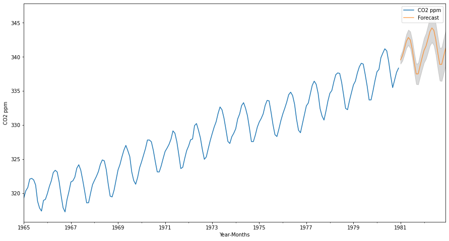

```python
# plot the forecast along with the confidence band

axis = df.plot(label='Observed', figsize=(15, 8))
forecast_fullmodel_autosarima.plot(ax=axis, label='Forecast', alpha=0.7)
axis.fill_between(forecast_fullmodel_autosarima.index, pred_ci_95['lower CO2 ppm'], pred_ci_95['upper CO2 ppm'], color='k', alpha=.15)
axis.set_xlabel('Year-Months')
axis.set_ylabel('CO2 ppm')
plt.legend(loc='best')
plt.show()
```

We see that we have certainly been able to take advantage of seasonality to get a better prediction with thinner confidence intervals.